# Statistical Methods

Continuous Moderation

Fall 2025 | Course PSYC 790  
Jeffrey M. Girard | Lecture 11a

# Overview

## Motivation

- Last week, we learned about multiple regression
- We used this to predict $y$ from multiple $x$ variables
- We accounted for the shared variance among $x$ variables
- We will now learn moderation (i.e., interaction effects)
- The effect of one $x$ *depends on* the value of another $x$
- This adds complexity and “contextualization” to models

## Example dataset

Imagine we are doing a study on exercise and energy use

```r
#install.packages("marginaleffects")
library(tidyverse)
exercise <- read_csv("exercise.csv")
exercise
## # A tibble: 900 × 6
##       id expenditure duration intensity sex   program
##    <dbl>       <dbl>    <dbl>     <dbl> <chr> <chr>
##  1     1       18.0      1.84      37.7 male  jog
##  2     2       10.2      2.39      26.7 male  jog
##  3     3       19.7      2.36      36.3 male  jog
##  4     4        1.88     2.52      20.7 male  jog
##  5     5       14.2      1.89      24.7 male  jog
##  6     6       19.7      2.37      33.7 male  jog
##  7     7       11.7      1.95      31.4 male  jog
##  8     8       22.0      2.21      39.7 male  jog
##  9     9        8.18     2.51      27.6 male  jog
## 10    10        5.03     2.17      19.2 male  jog
## # ℹ 890 more rows
```

## Exploratory analysis

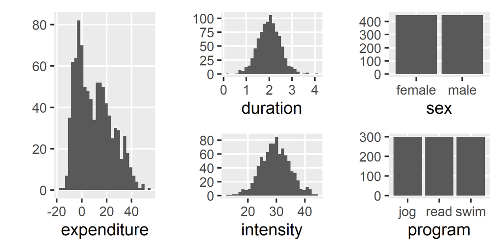

Note that this is simulated (i.e., fake) data.

## Moderation questions

**Continuous-by-Continuous Interaction**

- Does the effect of `duration` on `expenditure` depend on `intensity`?

**Continuous-by-Categorical Interaction**

- Does the effect of `duration` on `expenditure` depend on `sex`?

**Categorical-by-Categorical Interaction**

- Does the effect of `program` on `expenditure` depend on `sex`?

*Note that each question is statistically identical to its reverse (i.e., vice versa).*

# Continuous-by-Continuous

## Multiple regression recap

Let’s regress a continuous $y$ on two continuous $x$ variables

$$\hat{y} = b_0 + b_1 x_1 + b_2 x_2$$

- $b_0$ (intercept): the predicted $y$ when $x_1=0$ and $x_2=0$
- $b_1$ (partial): the change in $y$ for a change of +1 in $x_1$
- $b_2$ (partial): the change in $y$ for a change of +1 in $x_2$
- $b_1$ controls for $x_2$ but is the same across all values of $x_2$ and thus does not depend on it (and the same for $b_2$ and $x_1$)

## Adding an interaction

Interactions are formed by multiplying predictor variables

The product becomes another predictor with its own slope

$$\hat{y} = b_0 + b_1 x_1 + b_2 x_2 + b_3 \color{red}{x_1 x_2}$$

- $b_0$ (intercept): the predicted $y$ when $x_1=0$ and $x_2=0$
- $b_1$ (simple): the change in $y$ for a change of +1 in $x_1$ (specifically at $x_2=0$)
- $b_2$ (simple): the change in $y$ for a change of +1 in $x_2$ (specifically at $x_1=0$)
- $b_3$ (interaction): two equivalent definitions
  - the change in $b_1$ (i.e., the slope of $x_1$) for a change of +1 in $x_2$
  - the change in $b_2$ (i.e., the slope of $x_2$) for a change of +1 in $x_1$

## Rearranging the formula

$$\hat{y} = b_0 + b_1 x_1 + b_2 x_2 + b_3 x_1 x_2$$

$$\hat{y} = b_0 + (b_1 + b_3 x_2) x_1 + b_2 x_2$$

Thus, the slope of $x_1$ (its multiplier) *depends on* the value of $x_2$

Also, if there is no interaction ($b_3=0$), then $b_1$ is unchanged

The same is true for the slope of $x_2$ if we rearrange again

$$\hat{y} = b_0 + b_1 x_1 + (b_2 + b_3 x_1) x_2$$

## Interaction and simple effects

```r
fit <- lm(expenditure ~ duration + intensity + duration:intensity, data = exercise)
model_parameters(fit)
## Parameter            | Coefficient |    SE |          95% CI | t(896) |     p
## -----------------------------------------------------------------------------
## (Intercept)          |        7.80 | 11.60 | [-14.97, 30.57] |   0.67 | 0.502
## duration             |       -9.38 |  5.66 | [-20.49,  1.74] |  -1.66 | 0.098
## intensity            |       -0.08 |  0.38 | [ -0.84,  0.67] |  -0.21 | 0.835
## duration × intensity |        0.39 |  0.19 | [  0.03,  0.76] |   2.10 | 0.036
```

- The interaction effect (duration $\times$ intensity) is significant
- Thus, the effect of `duration` does depend on `intensity`

We can also use the shortcut `duration * intensity`

## Predicting energy expenditure

$$\hat{y} = 7.80 - 9.38 x_1 - 0.08 x_2 + 0.39 x_1 x_2$$

- **Intercept:** A participant exercising at 0 duration and 0 intensity expends 7.8 units
- **Duration Simple Effect:** Each unit of duration will expend an additional -9.38 units of energy (at 0 intensity)
- **Intensity Simple Effect:** Each unit of intensity will expend an additional -0.08 units of energy (at 0 duration)
- **Interaction Effect:** The slope of duration will increase by 0.39 for each unit of intensity, and the slope of intensity will increase by 0.39 for each unit of duration

The average participant (2 duration, 30 intensity) expends 10.04 units of energy

$$\hat{y} = 7.80 - 9.38(2) - 0.08(30) + 0.39(2)(30) = 10.04$$

## Spotlight analysis

- In order to plot the predictions, we can map one predictor to the $x$-axis
- But representing the other predictor continuously is challenging in 2D
- Instead of trying to use a 3D plot, we usually “spotlight” a few values, e.g.,
  - One SD below the mean $(\bar{x} - s_x)$
  - The mean value $(\bar{x})$
  - One SD above the mean $(\bar{x} + s_x)$
- We plot the effect of one $x$ on $y$ conditional on these values of the other $x$
  - Thus, these are often called “conditional effects plots”
  - You can think of “conditional on” as “depending on”

## Plotting interaction effects

```r
library(ggeffects)
plot(predict_response(fit, terms = c("duration", "intensity")))
```

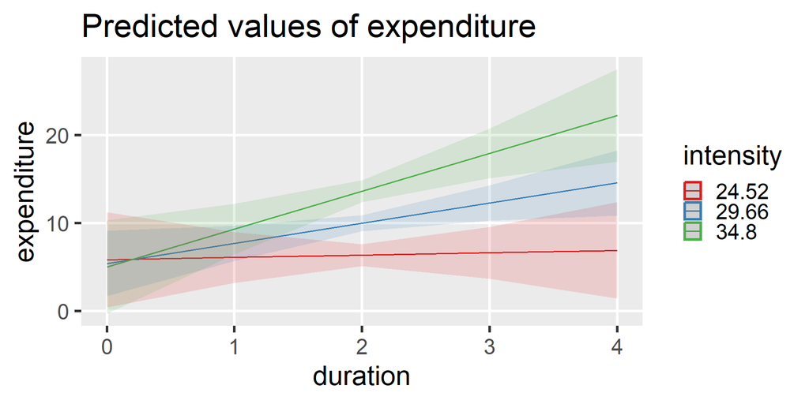

You can tell there is a non-zero interaction because the lines aren’t parallel.

## Plotting interaction effects

```r
plot(predict_response(fit, terms = c("intensity", "duration")))
```

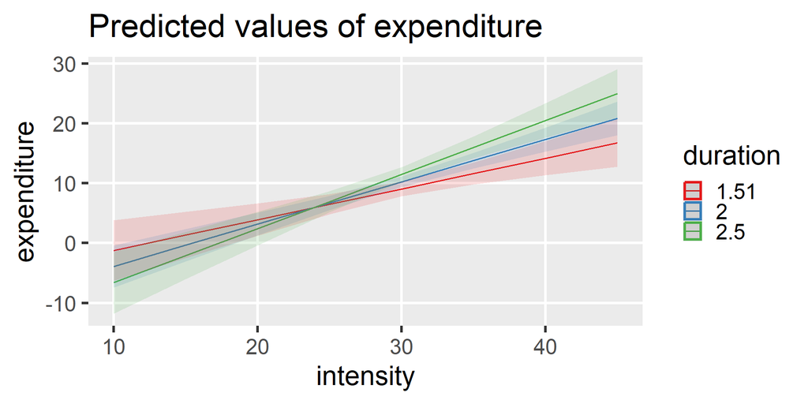

You can tell there is a non-zero interaction because the lines aren’t parallel.

## Simple slopes

- What is the slope of `duration` at different values of `intensity`?
  - With a non-zero interaction, the simple slopes will differ

```r
estimate_slopes(fit, trend = "duration", by = "intensity=c(0,15,30,45,60)")
## Estimated Marginal Effects
##
## intensity | Slope |   SE |          95% CI | t(896) |     p
## -----------------------------------------------------------
## 0         | -9.38 | 5.66 | [-20.49,  1.74] |  -1.66 | 0.098
## 15        | -3.48 | 2.92 | [ -9.21,  2.26] |  -1.19 | 0.235
## 30        |  2.42 | 0.92 | [  0.63,  4.22] |   2.65 | 0.008
## 45        |  8.32 | 2.99 | [  2.46, 14.19] |   2.78 | 0.005
## 60        | 14.23 | 5.73 | [  2.98, 25.47] |   2.48 | 0.013
##
## Marginal effects estimated for duration
## Type of slope was dY/dX
```

We could also use the shortcut `"intensity=[sd]"` to specify Mean $\pm$ SD

## Contrast with No Interaction

```r
fit2 <- lm(expenditure ~ duration + intensity, data = exercise)
model_parameters(fit2)
## Parameter   | Coefficient |   SE |          95% CI | t(897) |      p
## --------------------------------------------------------------------
## (Intercept) |      -15.60 | 3.20 | [-21.88, -9.32] |  -4.87 | < .001
## duration    |        2.35 | 0.92 | [  0.55,  4.15] |   2.56 | 0.010
## intensity   |        0.71 | 0.09 | [  0.53,  0.88] |   8.00 | < .001
```

- A participant exercising at 0 duration and 0 intensity expends -15.6 units
- Each additional unit of duration will expend 2.35 units (controlling `intensity`)
- Each additional unit of intensity will expend 0.71 units (controlling `duration`)
- The model predicts the same effect of duration at all values of intensity
- The model predicts the same effect of intensity at all values of duration

## Plotting partial effects

```r
plot(predict_response(fit2, terms = c("duration", "intensity")))
```

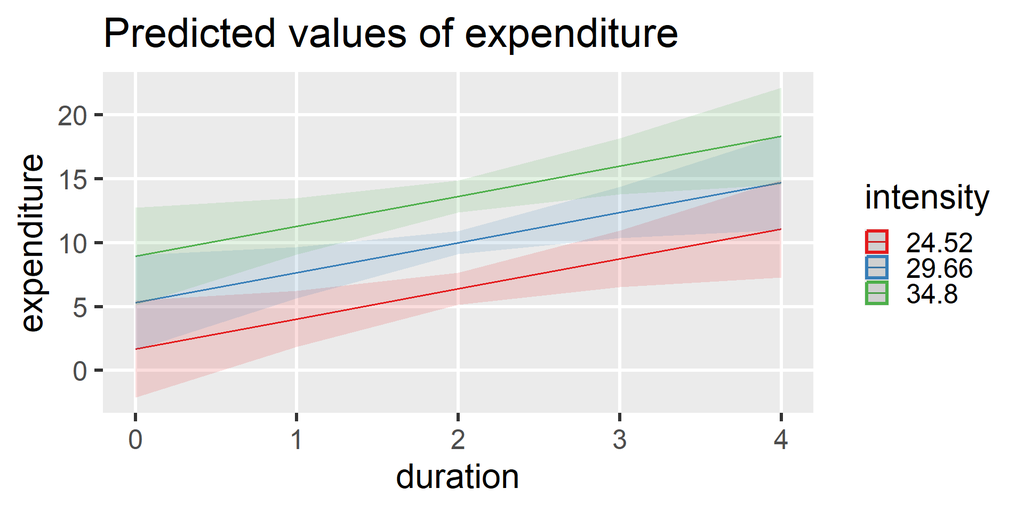

You can tell there is no interaction because the lines are parallel.

## Plotting partial effects

```r
plot(predict_response(fit2, terms = c("intensity", "duration")))
```

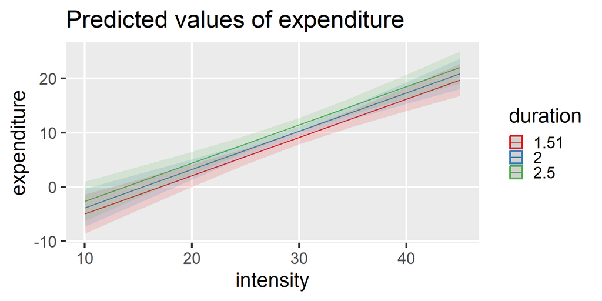

You can tell there is no interaction because the lines are parallel.

## Simple slopes

- In a model with no interaction, all simple slopes are equal

```r
estimate_slopes(fit2, trend = "duration", by = "intensity=[sd]")
## Estimated Marginal Effects
##
## intensity | Slope |   SE |       95% CI | t(897) |     p
## --------------------------------------------------------
## 24.52     |  2.35 | 0.92 | [0.55, 4.15] |   2.56 | 0.010
## 29.66     |  2.35 | 0.92 | [0.55, 4.15] |   2.56 | 0.010
## 34.80     |  2.35 | 0.92 | [0.55, 4.15] |   2.56 | 0.010
##
## Marginal effects estimated for duration
## Type of slope was dY/dX
```

# Interaction Patterns

## CxC Patterns

**Potentiation**

As one $x$ increases, the slope of the other increases

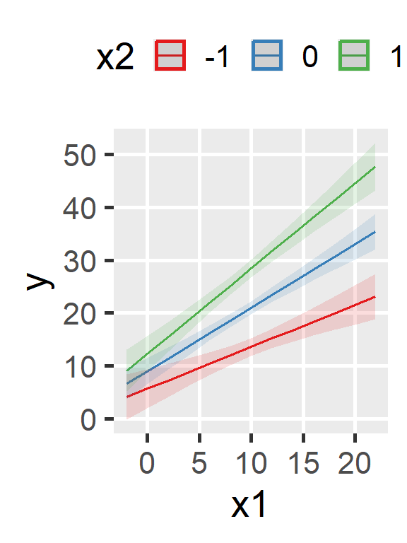

**Attenuation**

As one $x$ increases, the slope of the other decreases

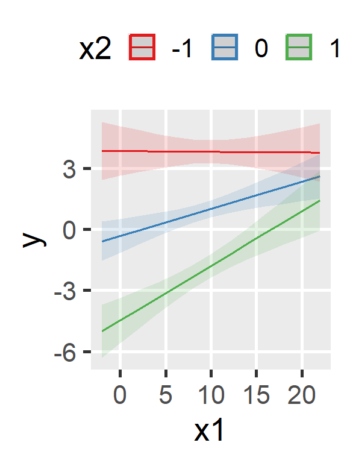

**Crossover**

As one $x$ increases, the ranking of the other reverses

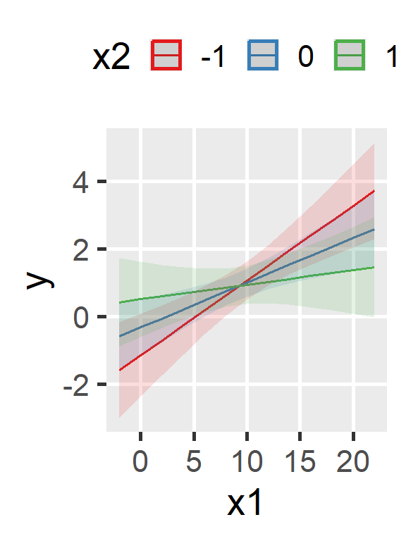

# Centering with Interactions

## Centering interactions

- Recall that the simple effects are when the other $x=0$
  - This means that their $p$ values only apply in that region
- So, if $x=0$ isn’t meaningful, we can use centering
  - Now they are the slopes when the other $x=\bar{x}$

```r
exercise$duration_c <- center(exercise$duration)
exercise$intensity_c <- center(exercise$intensity)
```

## Centering interactions

```r
fit3 <- lm(expenditure ~ duration_c * intensity_c, data = exercise)
model_parameters(fit3)
## Parameter                | Coefficient |   SE |        95% CI | t(896) |      p
## -------------------------------------------------------------------------------
## (Intercept)              |       10.00 | 0.45 | [9.12, 10.89] |  22.13 | < .001
## duration c               |        2.29 | 0.92 | [0.49,  4.09] |   2.50 | 0.012
## intensity c              |        0.71 | 0.09 | [0.53,  0.88] |   8.04 | < .001
## duration c × intensity c |        0.39 | 0.19 | [0.03,  0.76] |   2.10 | 0.036
```

- A participant with average duration and intensity expends 10.00 units
- Each added unit of duration expends 2.29 units of energy (at average intensity)
- Each added unit of intensity expends 0.71 units of energy (at average duration)
- The slope of duration will increase by 0.39 for each unit of intensity, and the slope of intensity will increase by 0.39 for each unit of duration

## Plotting centered interactions

```r
plot(predict_response(fit3, terms = c("duration_c", "intensity_c")))
```

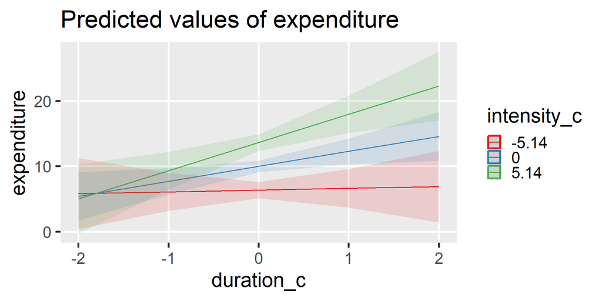

## Plotting centered interactions

```r
plot(predict_response(fit3, terms = c("intensity_c", "duration_c")))
```

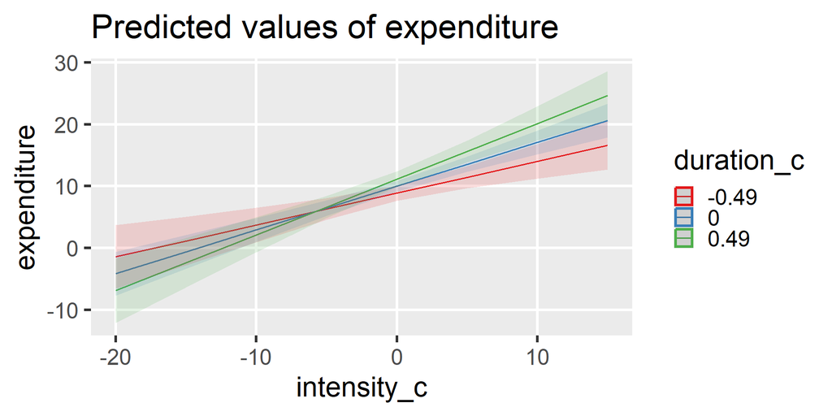

## Standardizing coefficients

- Don’t forget that standardizing includes centering!

```r
model_parameters(fit, standardize = "refit")
## Parameter            | Coefficient |   SE |        95% CI | t(896) |      p
## ---------------------------------------------------------------------------
## (Intercept)          |   -1.15e-03 | 0.03 | [-0.06, 0.06] |  -0.04 | 0.971
## duration             |        0.08 | 0.03 | [ 0.02, 0.14] |   2.50 | 0.012
## intensity            |        0.26 | 0.03 | [ 0.20, 0.32] |   8.04 | < .001
## duration × intensity |        0.07 | 0.03 | [ 0.00, 0.14] |   2.10 | 0.036
```

- Increasing duration by 1 SD expends another 0.08 SD (at *average* intensity)
- Increasing intensity by 1 SD expends another 0.26 SD (at *average* duration)
- Increasing duration by 1 SD increases the effect of intensity by 0.07 SDs and  
  increasing intensity by 1 SD increases the effect of duration by 0.07 SDs

## Recommendations

- Center your interacting continuous predictors
- Use domain knowledge to guide selection of interactions
- Plot your interaction effects to aid in communication
- Don’t include an interaction without its simple effects
- Don’t confuse simple effects and partial effects